# Wine Analysis by Himanshu Sharma

## Introduction

> Red_wine_quality dataset is one of the curated datasets provided by udacity.It is cleaned dataset containing 1,599 red wines with 11 variables on the chemical properties of the wine. There are 11 input variables and one output variable “Rating” which ranges between 0 (very bad) and 10 (very excellent).

```
##  [1] "X"                    "fixed.acidity"        "volatile.acidity"
##  [4] "citric.acid"          "residual.sugar"       "chlorides"
##  [7] "free.sulfur.dioxide"  "total.sulfur.dioxide" "density"
## [10] "pH"                   "sulphates"            "alcohol"
## [13] "quality"
```

# Univariate Plots Section

### Fixed Acidity

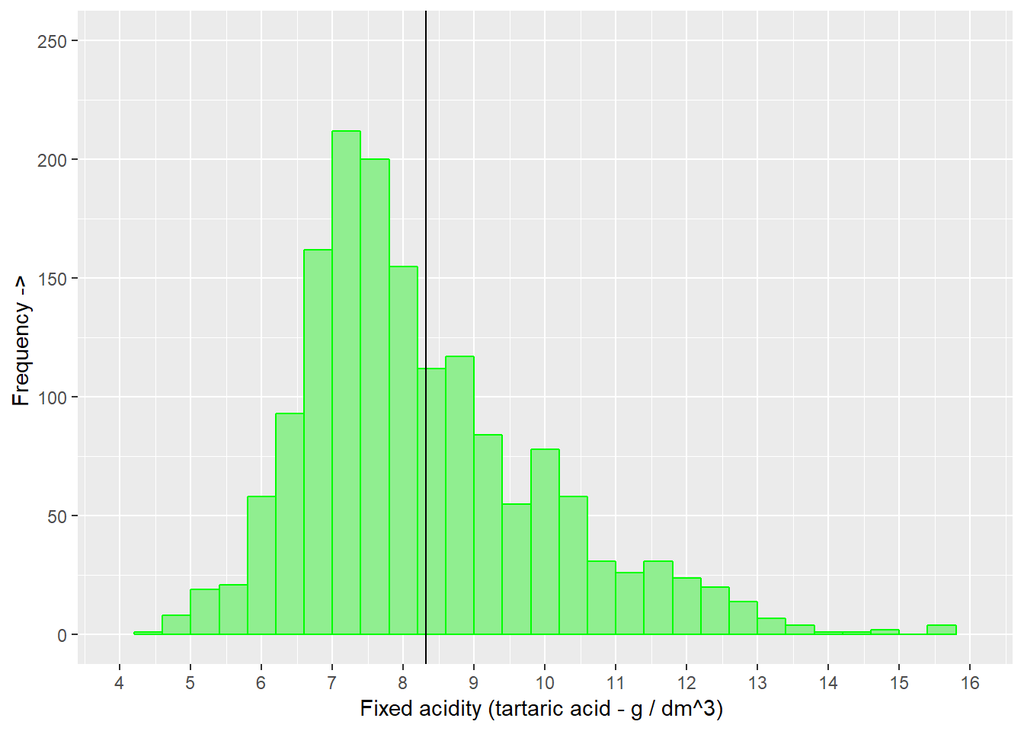

We can see from the graph that the data is slighly normall distributed plus a little bit of skewed at the right.The aveage value of the fixed acidity is 8.3

### Voltile Acidity

```
##    Min. 1st Qu.  Median    Mean 3rd Qu.    Max.
##  0.1200  0.3900  0.5200  0.5278  0.6400  1.5800
```

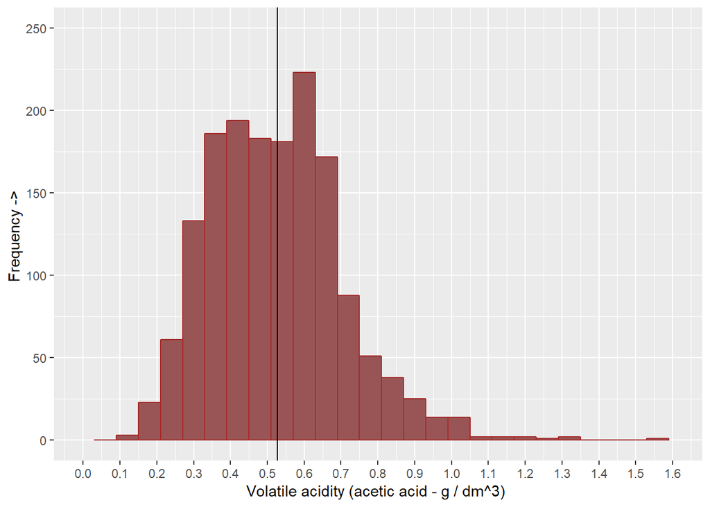

We can see from the above graph and summary that the volatile acidity is normally distributed and mean of volatile acidity is 0.5278 g/dm^3. There are outliers near 1.58.

### Citric Acid

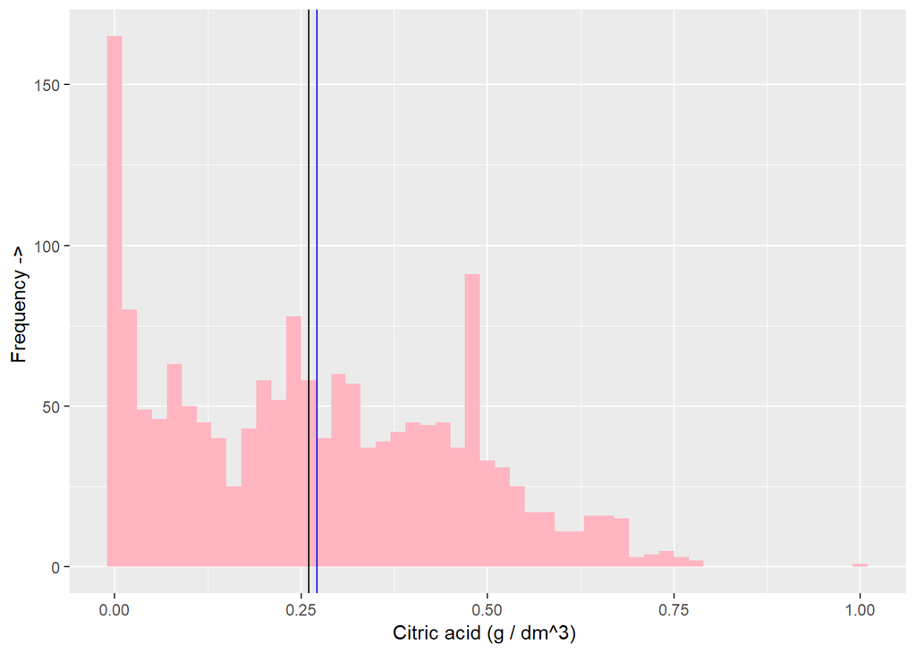

### Residual Sugar

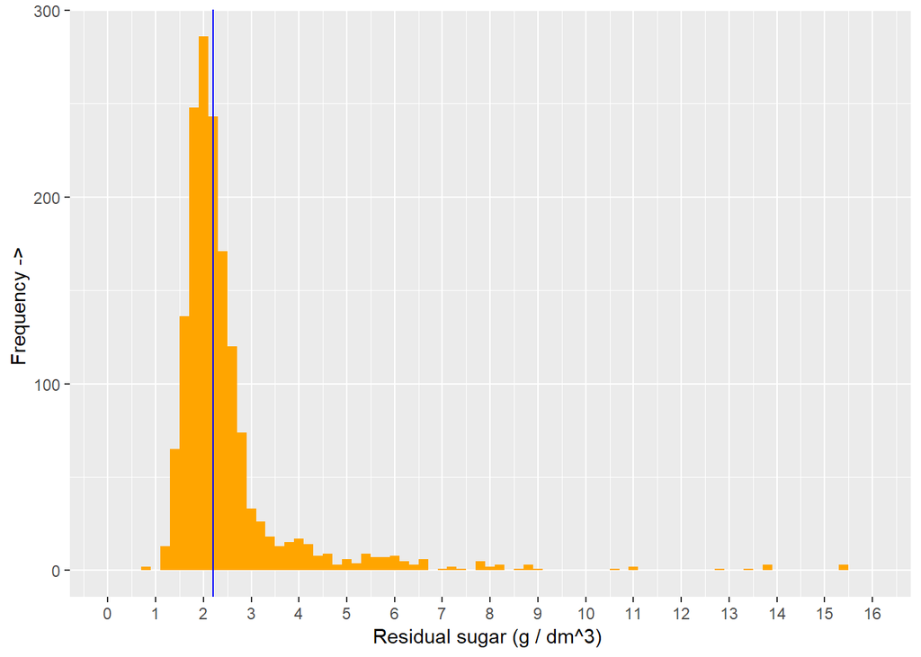

### Chlorides - Sodium Chloride

```
##    Min. 1st Qu.  Median    Mean 3rd Qu.    Max.
## 0.01200 0.07000 0.07900 0.08747 0.09000 0.61100
```

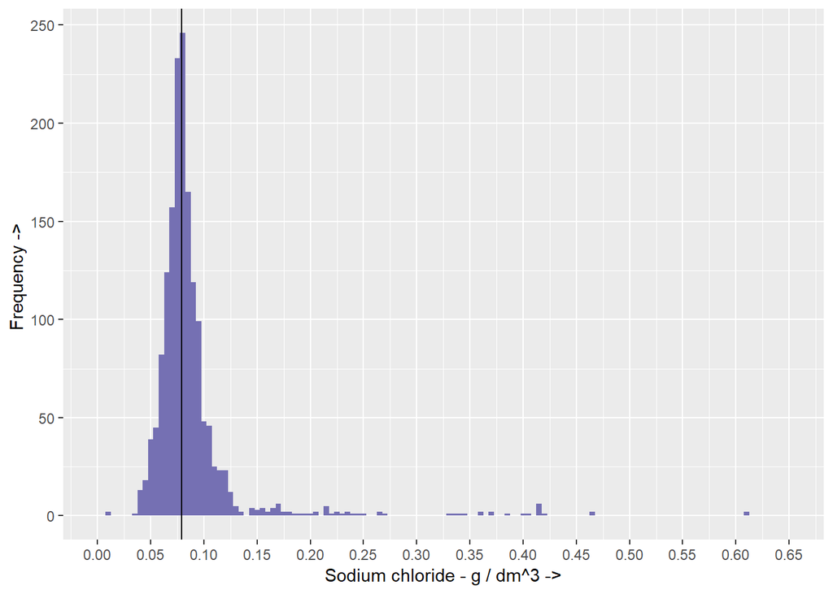

The data for chlorides is normally distributed with mean = 0.08747 g/dm^3 and there is an outlier or extreme value near 0.60.

### Free Sulphur Dioxide And Total Sulphur Dioxide

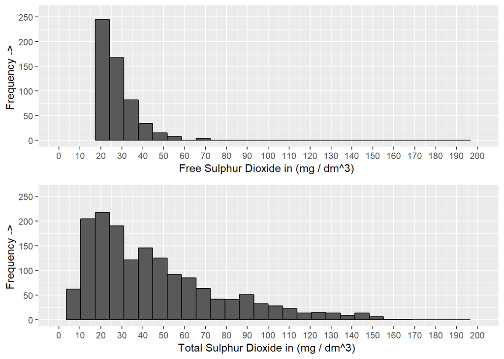

### Density

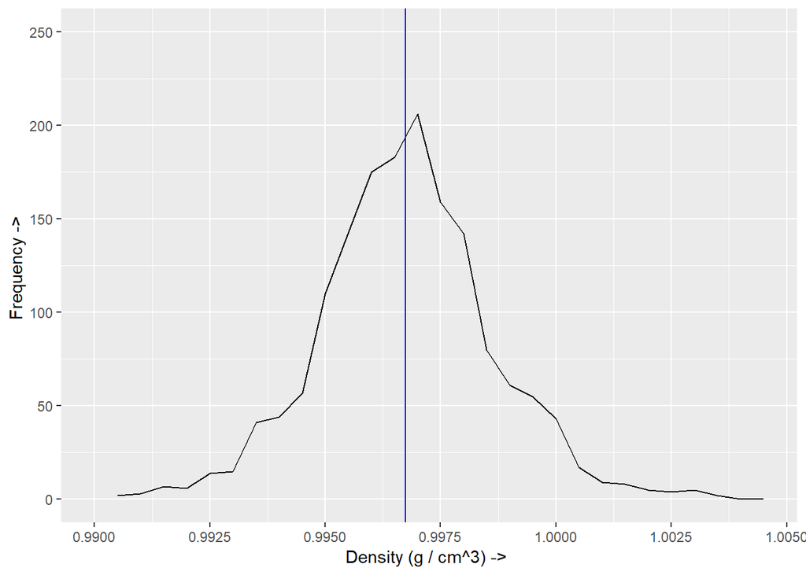

We can see from the above frequency polygon that the density is normally distributed and the average density in wines is 0.9971 g/cm^3.

### pH

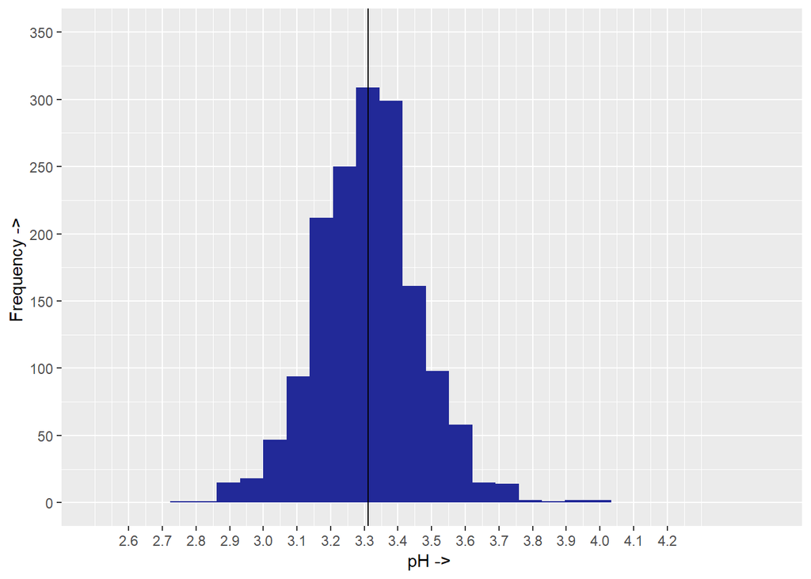

It seems that the pH is normally distributed and mean line is drawn on the graph where mean is nearly 3.31.

### Sulphates -Potassium sulphate

```
##    Min. 1st Qu.  Median    Mean 3rd Qu.    Max.
##  0.3300  0.5500  0.6200  0.6581  0.7300  2.0000
```

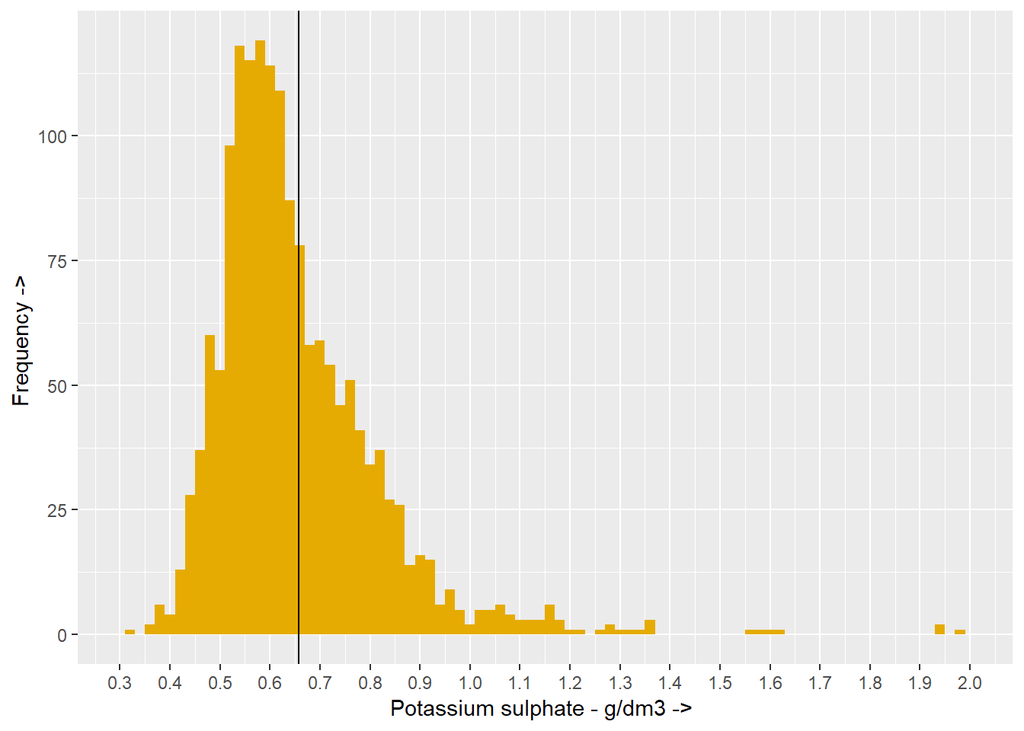

The data for sulphates is normally distributed with mean near 0.66 g/dm3 . Most of the values lies between 0.33 and 0.8 . There is an extreme case with potassium sulphate quantity = 2 g/dm3 .

### Alcohol_Content (% by volume)

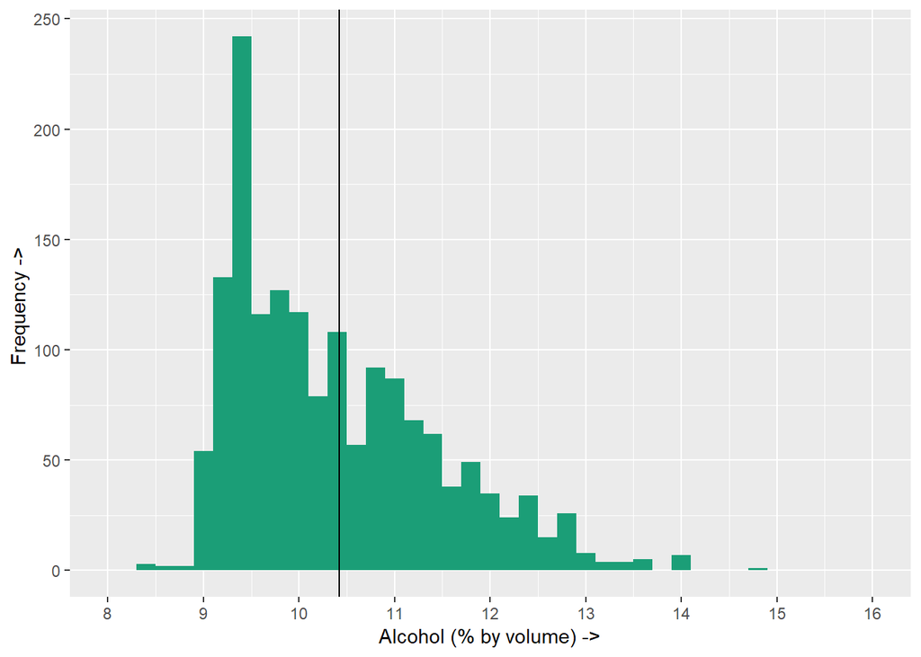

The alcohol content in the wines is skewed towards the right.Most of the wines contain 9-10 % of alcohol in them . And average alcohol percent lies near 10.5.

## The Output Variable

> The output variable for the dataset is Quality and it is score lying between 0 (very bad) and 10(very excellent).

### ->Alcohol Quality

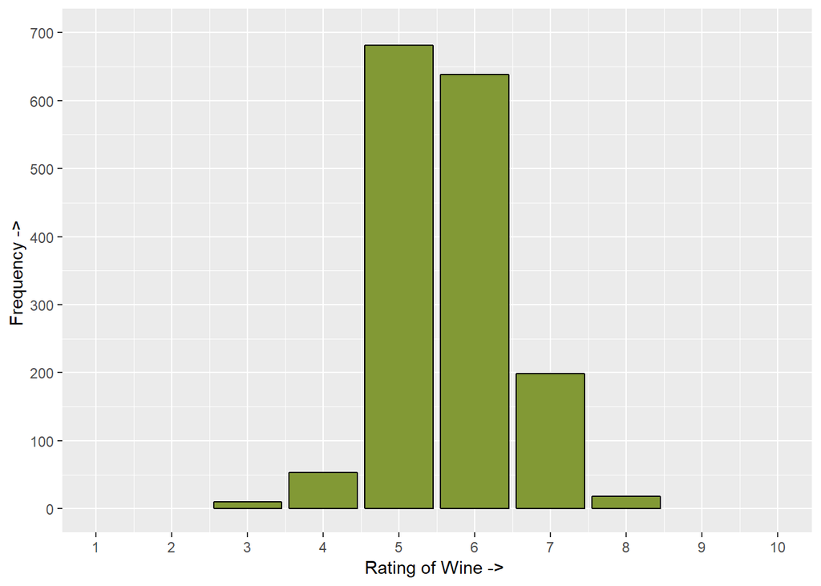

We can see that the most of the wines are of average rating 5-6. There are no wines having very low rating,i.e., from 1-2 and also there are no wines having very excellent rating,i.e., from 9-10.

# Univariate Analysis

> **Tip**: Now that you’ve completed your univariate explorations, it’s time to reflect on and summarize what you’ve found. Use the questions below to help you gather your observations and add your own if you have other thoughts!

### What is the structure of your dataset?

The dataset contains total of 12 variables and contains 1599 records of each variable.Out of 12 variables, 11 variables are on the chemical properties of the wine and the 12th variable is is a rating based on sensory data (median of at least 3 evaluations made by wine experts).

### What is/are the main feature(s) of interest in your dataset?

The main feature of interest in my dataset is the quality rating of wines.

### What other features in the dataset do you think will help support your investigation into your feature(s) of interest?

As i am a party animal and from my personal perspective, there are many variables affecting the quality of a wine, and a lot of variables are present in this dataset. Alcohol content,sulphur dioxides,sulphates,pH,citric acid will support my area of interest.

### Did you create any new variables from existing variables in the dataset?

No, i have not created any new variable , neither i think there is any need to create any new variable.

### Of the features you investigated, were there any unusual distributions? Did you perform any operations on the data to tidy, adjust, or change the form of the data? If so, why did you do this?

No i didn’t perform any operations on the data to clean, adjust, or change the form of the data. The data is already cleaned and all the variables are either normally distributed or are skewed either towards the right or left.

# Bivariate Plots Section

### Output variable Vs Supporting variables :-

#### Quality vs Fixed_Acidity

```
## # A tibble: 6 x 4
##   quality Mean_By_Quality Median_By_Quality     n
##     <int>           <dbl>             <dbl> <int>
## 1       3            8.36              7.5     10
## 2       4            7.78              7.5     53
## 3       5            8.17              7.8    681
## 4       6            8.35              7.9    638
## 5       7            8.87              8.8    199
## 6       8            8.57              8.25    18
```

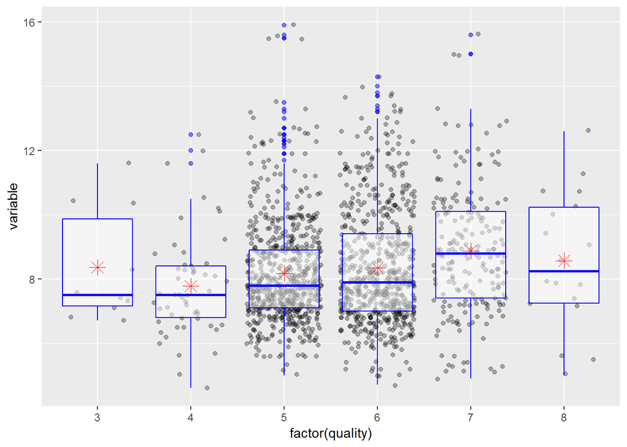

#### Quality vs Volatile_Acidity

```
## # A tibble: 6 x 4
##   quality Mean_By_Quality Median_By_Quality     n
##     <int>           <dbl>             <dbl> <int>
## 1       3           0.884             0.845    10
## 2       4           0.694             0.67     53
## 3       5           0.577             0.580   681
## 4       6           0.497             0.49    638
## 5       7           0.404             0.37    199
## 6       8           0.423             0.37     18
```

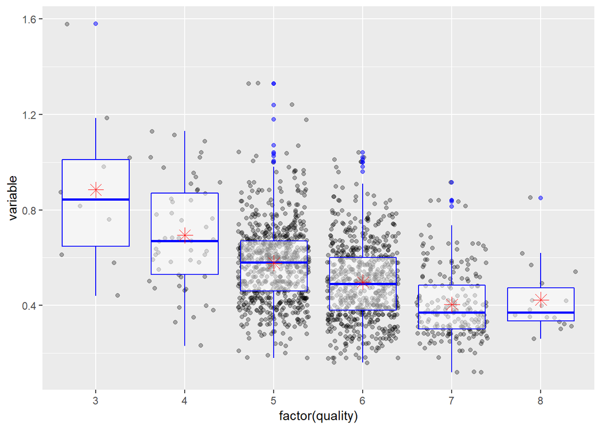

We can see from the above table and graph that lower volatile_acidity leads to increase in the quality of wine and the relationship seems to be a good linear relation.

#### Quality vs Citric_Acid

```
## # A tibble: 6 x 4
##   quality Mean_By_Quality Median_By_Quality     n
##     <int>           <dbl>             <dbl> <int>
## 1       3           0.171             0.035    10
## 2       4           0.174             0.09     53
## 3       5           0.244             0.23    681
## 4       6           0.274             0.26    638
## 5       7           0.375             0.4     199
## 6       8           0.391             0.42     18
```

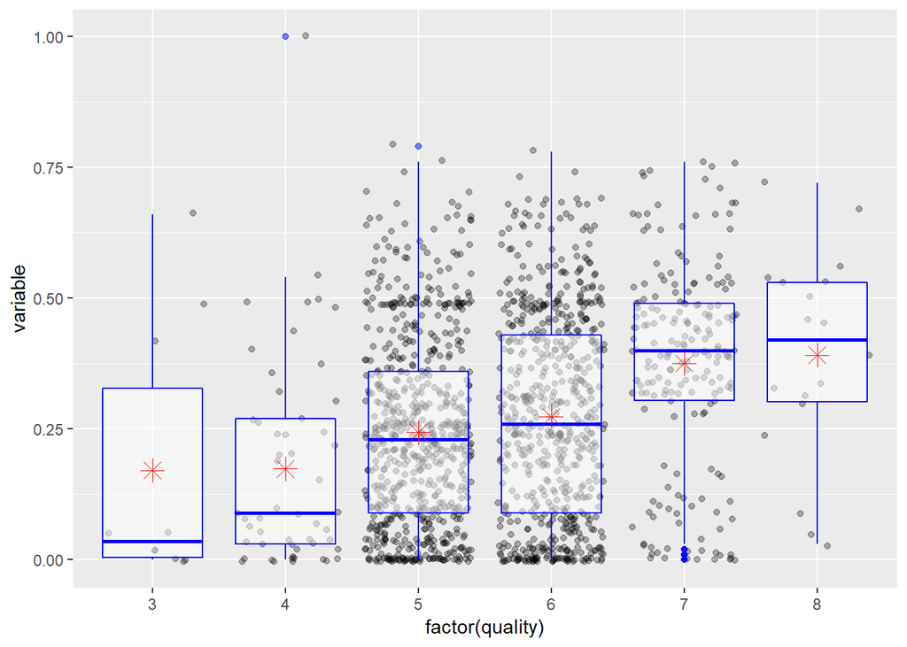

We can see from the above table and graph that with increase in citric_acid there is increase in the quality of wine and the relationship is linear.

#### Quality vs Residual_Sugar

```
## # A tibble: 6 x 4
##   quality Mean_By_Quality Median_By_Quality     n
##     <int>           <dbl>             <dbl> <int>
## 1       3            2.64               2.1    10
## 2       4            2.69               2.1    53
## 3       5            2.53               2.2   681
## 4       6            2.48               2.2   638
## 5       7            2.72               2.3   199
## 6       8            2.58               2.1    18
```

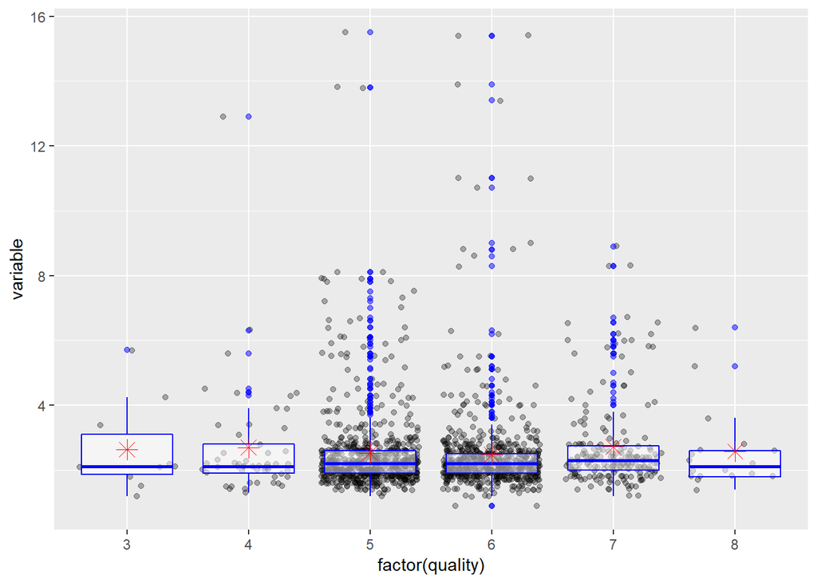

We can see from the above table and graph that there is no such relationship betweeen residual sugar and the quality of the wine .Although the residual sugar is on an average 2.5 g/dm^3 in wines.

#### Quality vs Chlorides

```
## # A tibble: 6 x 4
##   quality Mean_By_Quality Median_By_Quality     n
##     <int>           <dbl>             <dbl> <int>
## 1       3          0.122             0.0905    10
## 2       4          0.0907            0.08      53
## 3       5          0.0927            0.081    681
## 4       6          0.0850            0.078    638
## 5       7          0.0766            0.073    199
## 6       8          0.0684            0.0705    18
```

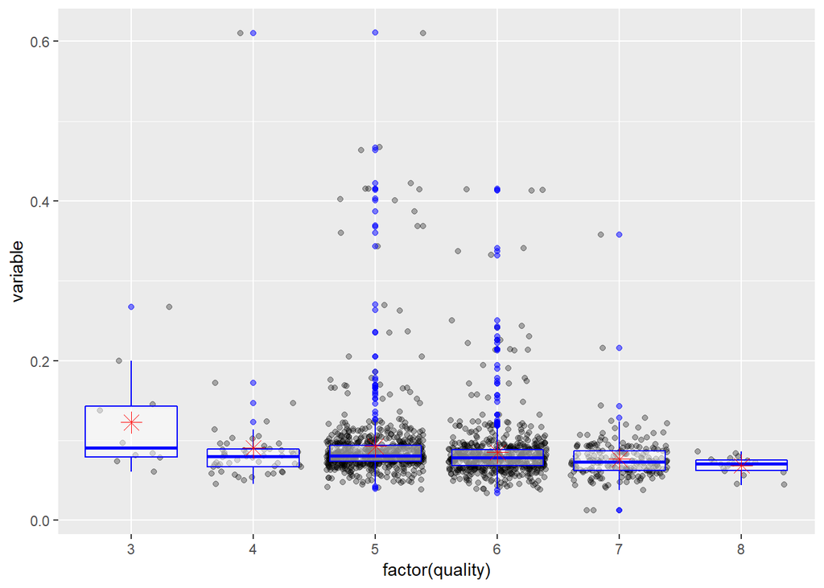

#### Quality vs Free_Sulphur_Dioxide

```
## # A tibble: 6 x 4
##   quality Mean_By_Quality Median_By_Quality     n
##     <int>           <dbl>             <dbl> <int>
## 1       3            11                 6      10
## 2       4            12.3              11      53
## 3       5            17.0              15     681
## 4       6            15.7              14     638
## 5       7            14.0              11     199
## 6       8            13.3               7.5    18
```

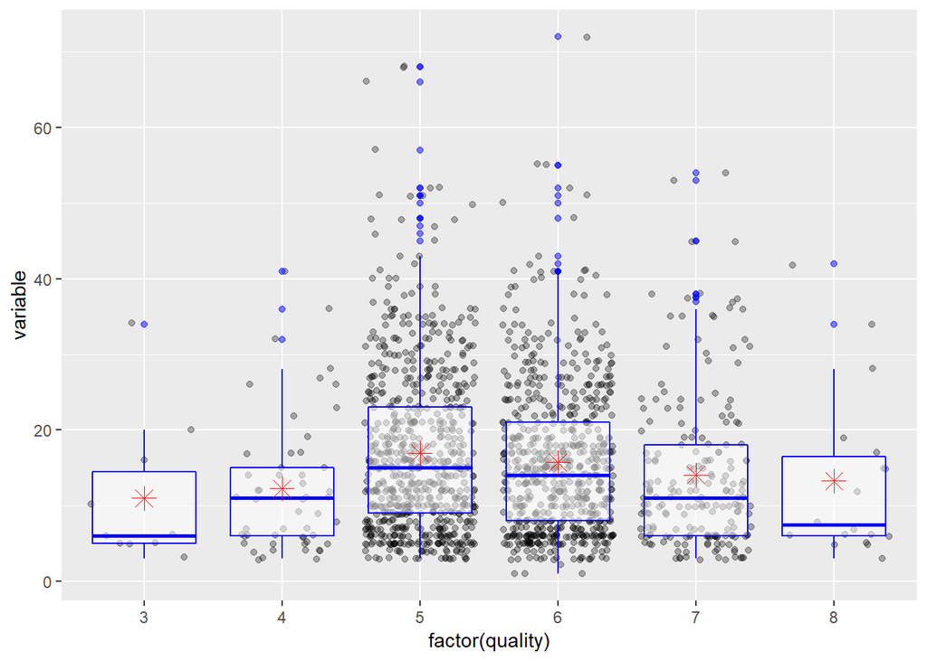

From the above table and graph we can see that there is no such relationship between the free_sulphur_dioxide and the quality of the wine . It increases till the average quality and then decreases till the highest quality.

#### Quality vs Total_Sulphur_Dioxide

```
## # A tibble: 6 x 4
##   quality Mean_By_Quality Median_By_Quality     n
##     <int>           <dbl>             <dbl> <int>
## 1       3            24.9              15      10
## 2       4            36.2              26      53
## 3       5            56.5              47     681
## 4       6            40.9              35     638
## 5       7            35.0              27     199
## 6       8            33.4              21.5    18
```

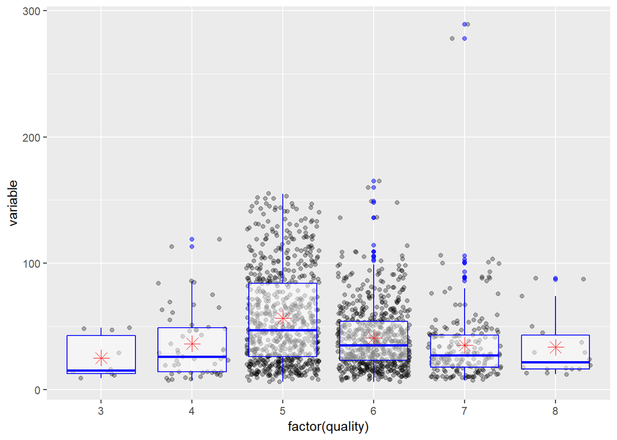

From the above table and graph we can see that there is no such relationship between the total_sulphur_dioxide and the quality of the wine like frees_sulphur_dioxide . It increases till the average quality and then decreases till the highest quality.

#### Quality vs Density

```
## # A tibble: 6 x 4
##   quality Mean_By_Quality Median_By_Quality     n
##     <int>           <dbl>             <dbl> <int>
## 1       3           0.997             0.998    10
## 2       4           0.997             0.996    53
## 3       5           0.997             0.997   681
## 4       6           0.997             0.997   638
## 5       7           0.996             0.996   199
## 6       8           0.995             0.995    18
```

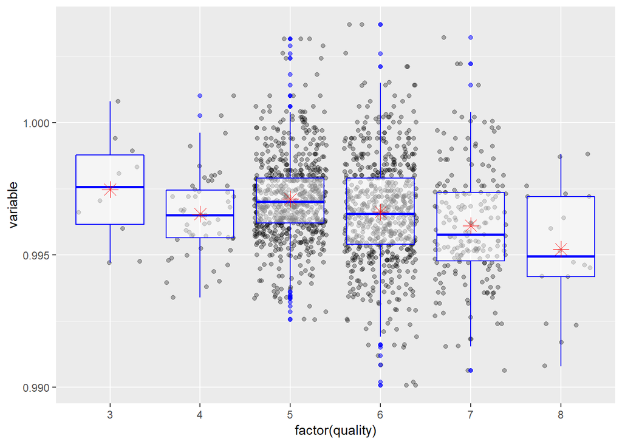

The above table and graph represents that there is a minimal decrease in density with increase in the quality of the wine.

#### Quality vs pH

```
## # A tibble: 6 x 4
##   quality Mean_By_Quality Median_By_Quality     n
##     <int>           <dbl>             <dbl> <int>
## 1       3            3.40              3.39    10
## 2       4            3.38              3.37    53
## 3       5            3.30              3.3    681
## 4       6            3.32              3.32   638
## 5       7            3.29              3.28   199
## 6       8            3.27              3.23    18
```

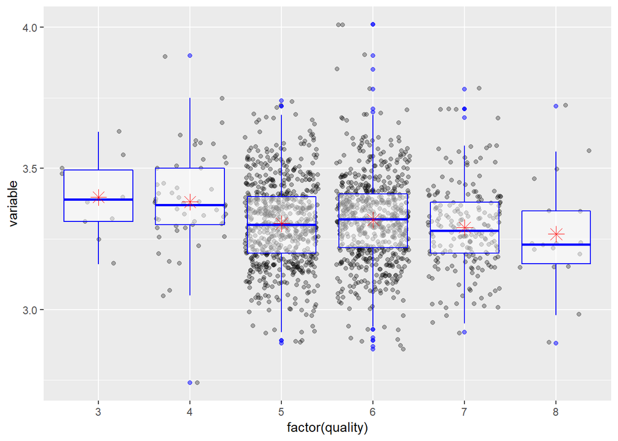

We can see from the above graph and table that the pH amount is decreasing with respect to the increase in the quality of the wine.

#### Quality vs Sulphates

```
## # A tibble: 6 x 4
##   quality Mean_By_Quality Median_By_Quality     n
##     <int>           <dbl>             <dbl> <int>
## 1       3           0.57              0.545    10
## 2       4           0.596             0.56     53
## 3       5           0.621             0.580   681
## 4       6           0.675             0.64    638
## 5       7           0.741             0.74    199
## 6       8           0.768             0.74     18
```

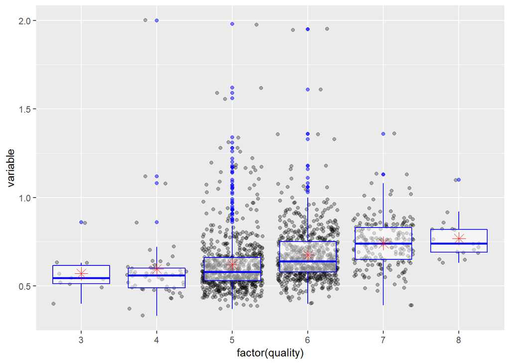

#### Quality vs Alcohol_Content

```
## # A tibble: 6 x 4
##   quality Mean_By_Quality Median_By_Quality     n
##     <int>           <dbl>             <dbl> <int>
## 1       3            9.96              9.93    10
## 2       4           10.3              10       53
## 3       5            9.90              9.7    681
## 4       6           10.6              10.5    638
## 5       7           11.5              11.5    199
## 6       8           12.1              12.2     18
```

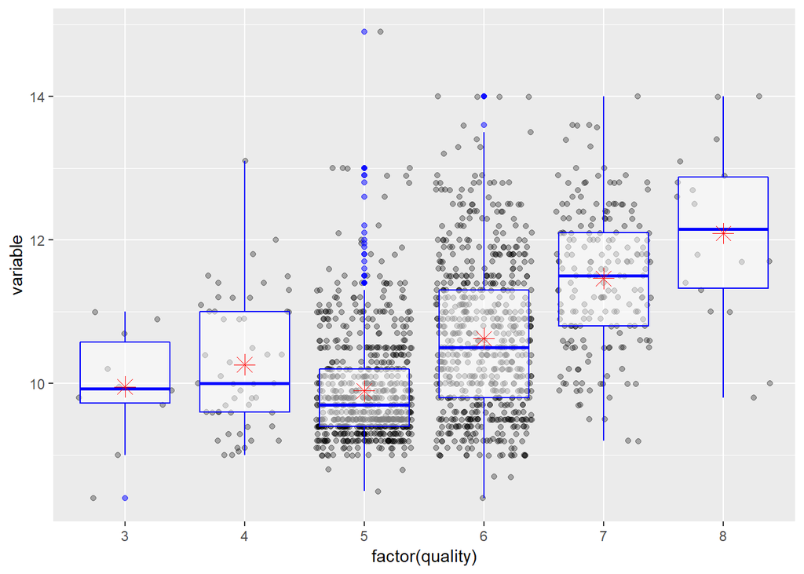

We can see that there is a straight increase in the alcohol content with respect to increase in the quality of the wine from average to wine with the best quality. And it is obvious too the wine with a little more alcohol content have a little higher quality and rating with compare to the other.

### Observing any interesting relationships between the other features

#### Co-relation Heatmap Between Features

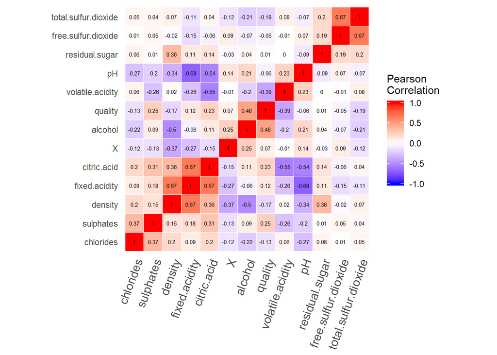

As two variables having correlation coefficient greater than 0.5 are considered to poccess a good relationship between them, so they will taken under focus.

#### fixed_acidity vs density

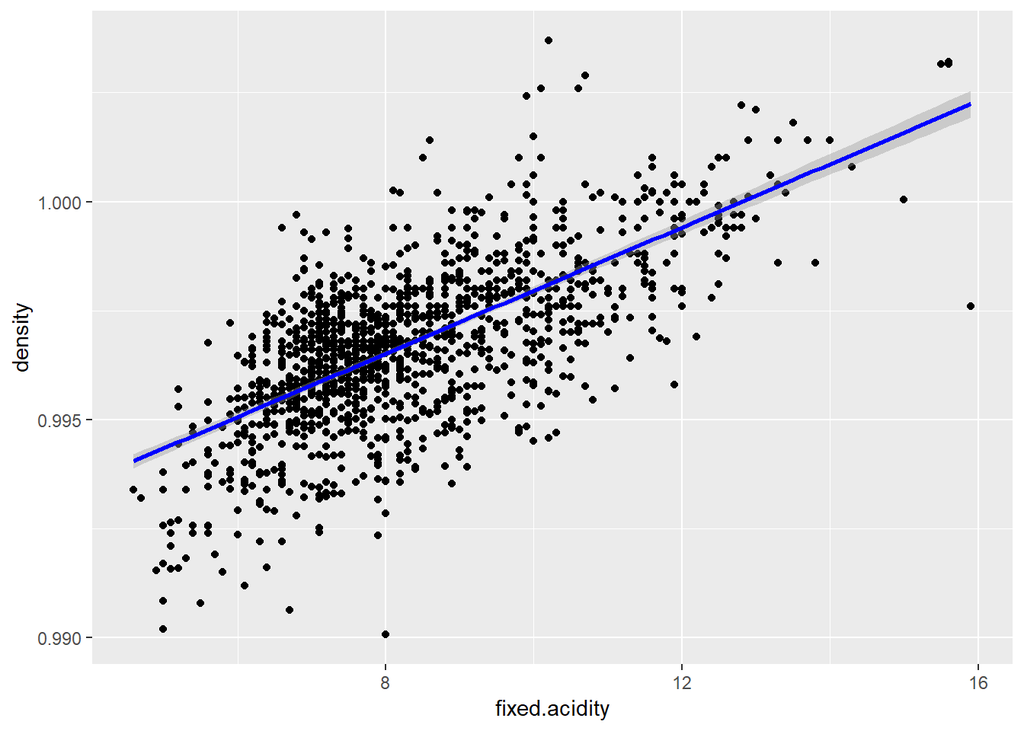

With increase in the fixed.acidity content , the density of the wine is also increasing.

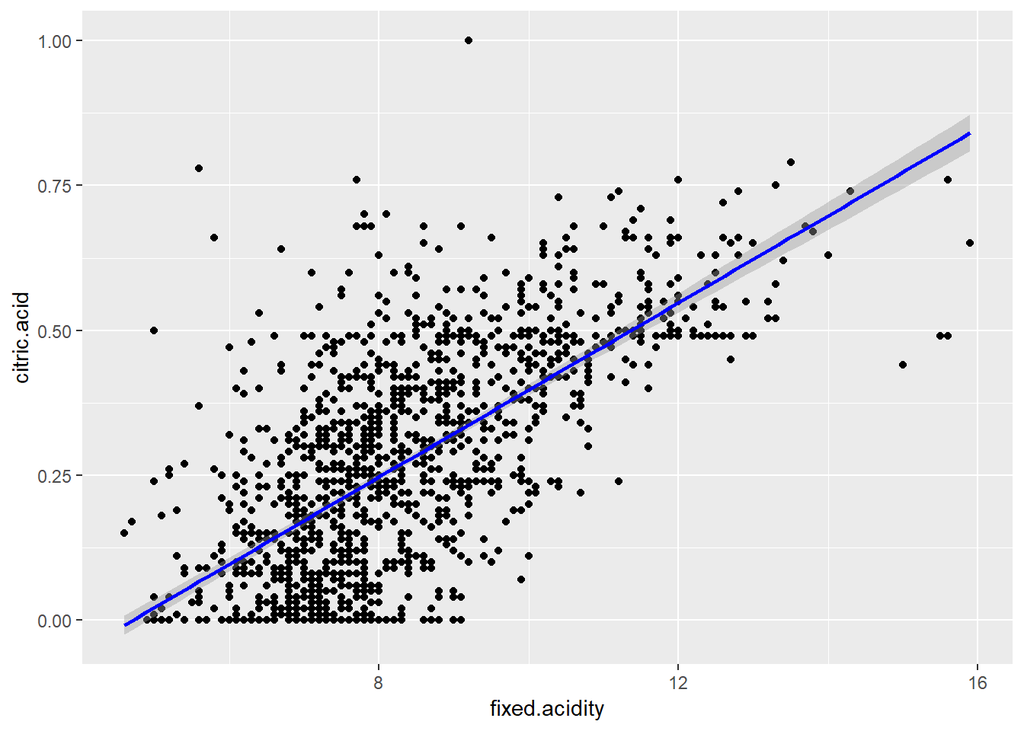

With increase in the fixed.acidity content , the citric.acid ratio of the wine is also increasing.

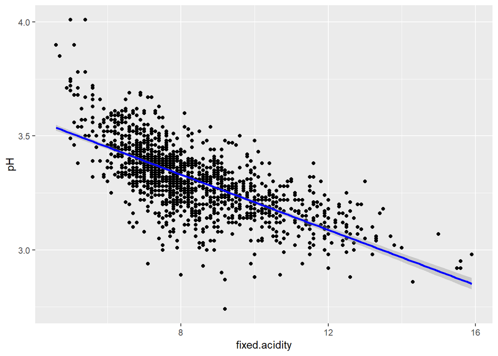

With increase in the fixed.acidity content , the pH value of the wine is decreasing.

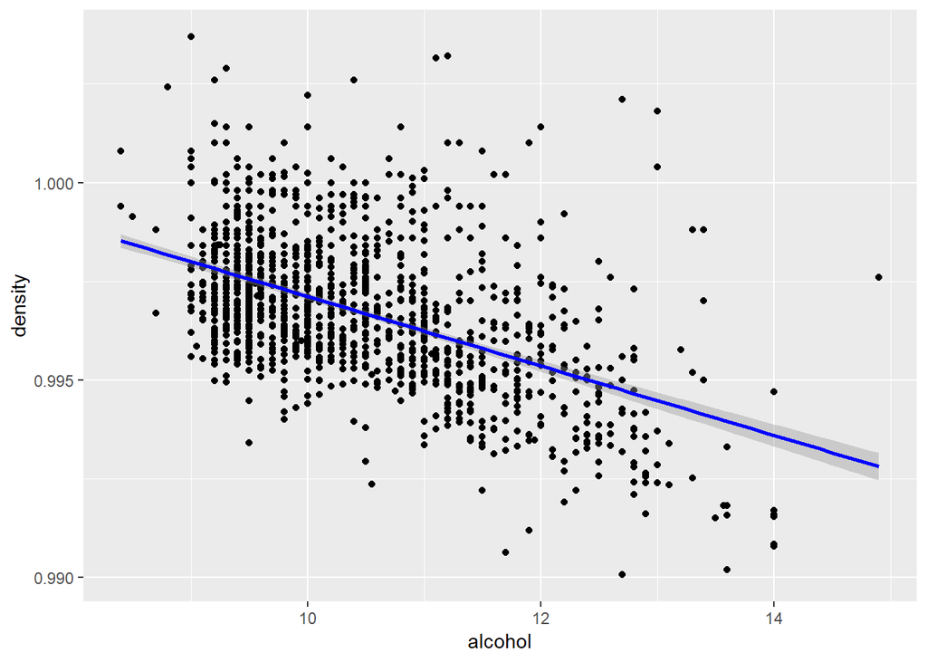

With increase in the alcohol content , the density of the wine is decreasing.

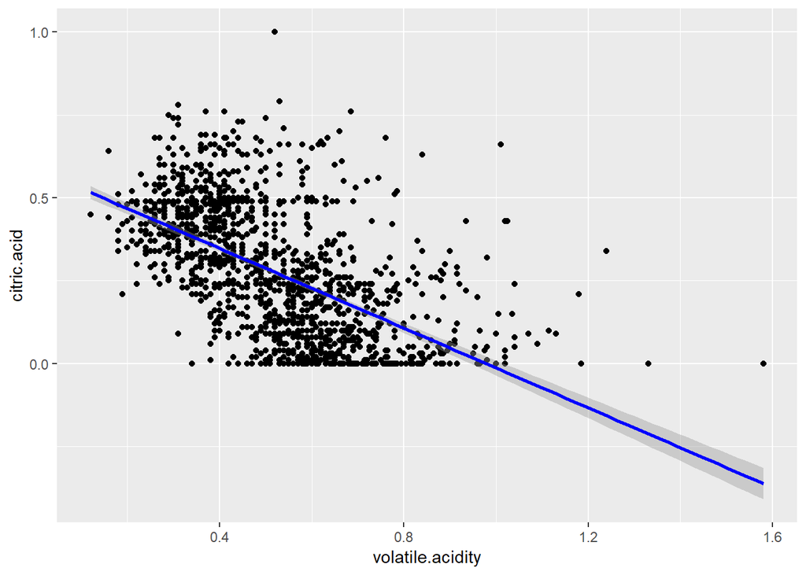

With increase in the volatile acidity , the citric acid content of the wine is decreasing.

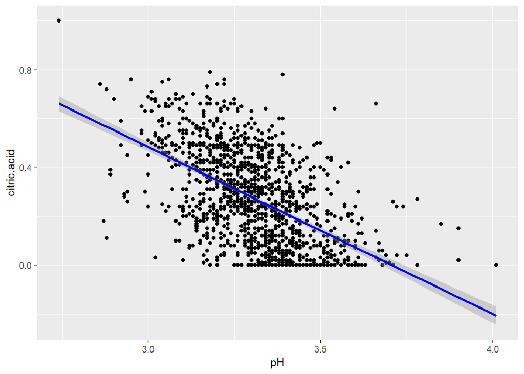

With increase in the citric acid content , the pH value of the wine is decreasing.

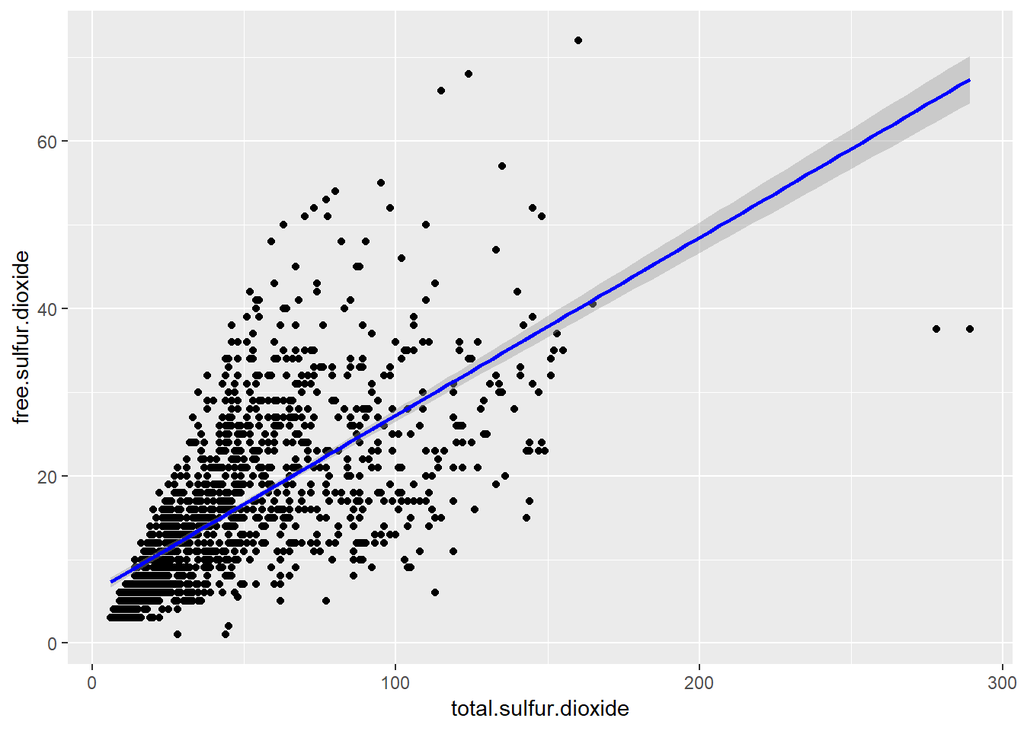

The total.sulfur.dioxide and free.sulfur.dioxide contents are proportional to each other.

# Bivariate Analysis

### Did you observe any interesting relationships between the other features (not the main feature(s) of interest)?

##### ->With increase in the fixed.acidity content , the density of the wine is also increasing.

##### ->With increase in the fixed.acidity content , the citric.acid ratio of the wine is also increasing.

##### ->With increase in the fixed.acidity content , the pH value of the wine is decreasing.

##### ->With increase in the alcohol content , the density of the wine is decreasing.

##### ->With increase in the volatile acidity , the citric acid content of the wine is decreasing.

##### ->With increase in the citric acid content , the pH value of the wine is decreasing.

##### ->The total.sulfur.dioxide and free.sulfur.dioxide contents are proportional to each other.

### What was the strongest relationship you found?

##### ->According to the heatmap and correlation coefficients the strongest relation of quality is with alcohol content.